# **Problem Statement**

#### The objective of this report is to conduct univariate linear regression analysis using the California Housing Prices dataset. The main focus of this analysis is to identify how the median income, population, and the number of households individually influence the median house value. The insights gained here can guide the various stakeholders in making informed decisions about housing and urban development.

# **Getting Data**

Import Packages

```python
import pandas as pd
import matplotlib.pyplot as plt
import seaborn as sns
from sklearn import linear_model
from sklearn.metrics import mean_absolute_error, mean_squared_error
```

Data Source : [Link to Data](https://www.kaggle.com/datasets/camnugent/california-housing-prices)

```python
df = pd.read_csv('data/housing.csv')
df
```

|  | longitude | latitude | housing_median_age | total_rooms | total_bedrooms | population | households | median_income | median_house_value | ocean_proximity |
| --- | --- | --- | --- | --- | --- | --- | --- | --- | --- | --- |
| 0 | -122.23 | 37.88 | 41.0 | 880.0 | 129.0 | 322.0 | 126.0 | 8.3252 | 452600.0 | NEAR BAY |
| 1 | -122.22 | 37.86 | 21.0 | 7099.0 | 1106.0 | 2401.0 | 1138.0 | 8.3014 | 358500.0 | NEAR BAY |
| 2 | -122.24 | 37.85 | 52.0 | 1467.0 | 190.0 | 496.0 | 177.0 | 7.2574 | 352100.0 | NEAR BAY |
| 3 | -122.25 | 37.85 | 52.0 | 1274.0 | 235.0 | 558.0 | 219.0 | 5.6431 | 341300.0 | NEAR BAY |
| 4 | -122.25 | 37.85 | 52.0 | 1627.0 | 280.0 | 565.0 | 259.0 | 3.8462 | 342200.0 | NEAR BAY |
| ... | ... | ... | ... | ... | ... | ... | ... | ... | ... | ... |
| 20635 | -121.09 | 39.48 | 25.0 | 1665.0 | 374.0 | 845.0 | 330.0 | 1.5603 | 78100.0 | INLAND |
| 20636 | -121.21 | 39.49 | 18.0 | 697.0 | 150.0 | 356.0 | 114.0 | 2.5568 | 77100.0 | INLAND |
| 20637 | -121.22 | 39.43 | 17.0 | 2254.0 | 485.0 | 1007.0 | 433.0 | 1.7000 | 92300.0 | INLAND |
| 20638 | -121.32 | 39.43 | 18.0 | 1860.0 | 409.0 | 741.0 | 349.0 | 1.8672 | 84700.0 | INLAND |
| 20639 | -121.24 | 39.37 | 16.0 | 2785.0 | 616.0 | 1387.0 | 530.0 | 2.3886 | 89400.0 | INLAND |

20640 rows × 10 columns

# **Exploratory Data Analysis**

## Explore Data

```python
df_head = df.head()
print(df_head)
```

```
   longitude  latitude  housing_median_age  total_rooms  total_bedrooms
0    -122.23     37.88                41.0        880.0           129.0  \
1    -122.22     37.86                21.0       7099.0          1106.0
2    -122.24     37.85                52.0       1467.0           190.0
3    -122.25     37.85                52.0       1274.0           235.0
4    -122.25     37.85                52.0       1627.0           280.0

   population  households  median_income  median_house_value ocean_proximity
0       322.0       126.0         8.3252            452600.0        NEAR BAY
1      2401.0      1138.0         8.3014            358500.0        NEAR BAY
2       496.0       177.0         7.2574            352100.0        NEAR BAY
3       558.0       219.0         5.6431            341300.0        NEAR BAY
4       565.0       259.0         3.8462            342200.0        NEAR BAY
```

## Explore Statistics

```python
df_stats = df.describe()
print(df_stats)
```

```
          longitude      latitude  housing_median_age   total_rooms
count  20640.000000  20640.000000        20640.000000  20640.000000  \
mean    -119.569704     35.631861           28.639486   2635.763081
std        2.003532      2.135952           12.585558   2181.615252
min     -124.350000     32.540000            1.000000      2.000000
25%     -121.800000     33.930000           18.000000   1447.750000
50%     -118.490000     34.260000           29.000000   2127.000000
75%     -118.010000     37.710000           37.000000   3148.000000
max     -114.310000     41.950000           52.000000  39320.000000

       total_bedrooms    population    households  median_income
count    20433.000000  20640.000000  20640.000000   20640.000000  \
mean       537.870553   1425.476744    499.539680       3.870671
std        421.385070   1132.462122    382.329753       1.899822
min          1.000000      3.000000      1.000000       0.499900
25%        296.000000    787.000000    280.000000       2.563400
50%        435.000000   1166.000000    409.000000       3.534800
75%        647.000000   1725.000000    605.000000       4.743250
max       6445.000000  35682.000000   6082.000000      15.000100

       median_house_value
count        20640.000000
mean        206855.816909
std         115395.615874
min          14999.000000
25%         119600.000000
50%         179700.000000
75%         264725.000000
max         500001.000000
```

## Explore Variables

```python
df_key_variables = ['median_house_value', 'median_income', 'population', 'households']
df_key_variable_stats = df[df_key_variables].describe()
print(df_key_variable_stats)
```

```
       median_house_value  median_income    population    households
count        20640.000000   20640.000000  20640.000000  20640.000000
mean        206855.816909       3.870671   1425.476744    499.539680
std         115395.615874       1.899822   1132.462122    382.329753
min          14999.000000       0.499900      3.000000      1.000000
25%         119600.000000       2.563400    787.000000    280.000000
50%         179700.000000       3.534800   1166.000000    409.000000
75%         264725.000000       4.743250   1725.000000    605.000000
max         500001.000000      15.000100  35682.000000   6082.000000
```

Observations:

Median House: Range from $14,999 to $500,001. This can indicate diverse housing prices across different areas.

Median Income: Range from $0.4999 to $15.0001. The maximum value of Median Income seems high compared to rest of the data and might be an outlier

Population: Range from 3 to 35,682.

Number of households: Range from 1 to 6,082.

Overall the dataset exhibits significant variability in each variable. Potential outliers are noticeable in median income, population, and number of households. So the next step would be to visualize the distribution of each variable which will provide valuable insights for further analysis and modeling.

## Visualization

### **median house value vs. median income**

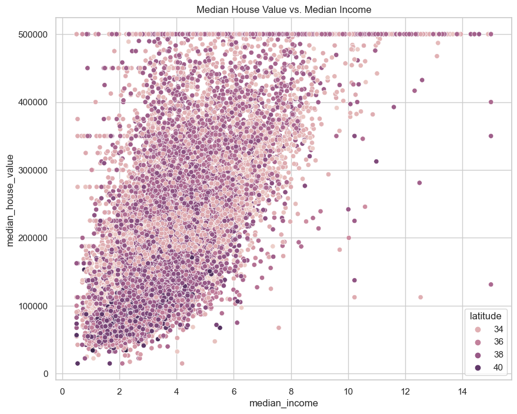

```python
sns.set(style="whitegrid")
plt.figure(figsize=(10, 8))
sns.scatterplot(data=df, x="median_income", y="median_house_value" , hue="latitude").set(title='Median House Value vs. Median Income')
plt.grid(True)
plt.show()
```

Observations :

- The plot shows a strong positive relationship between median income and median house value
- There is clustering of data points at the lower end of x and y axes which could indicate that the large no. of datapoints fall into lower median income and lower median house value
- The plot also shows that the median_house_value is capped at 500,001. This could potentially affect the analysis because the actual house values might be significantly higher than this cap.

### **median house value vs. population**

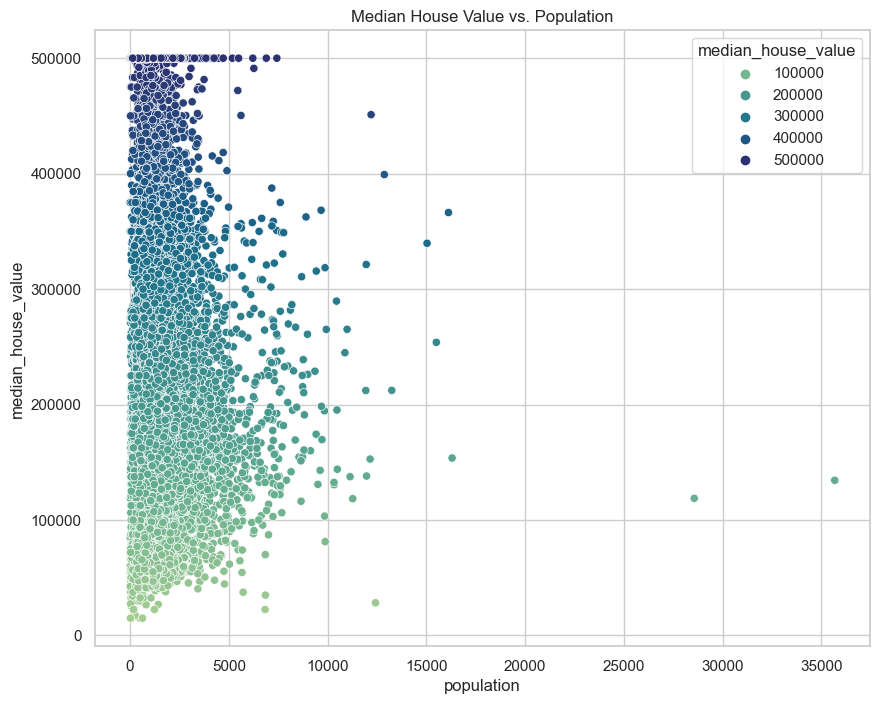

```python
sns.set(style="whitegrid")
plt.figure(figsize=(10, 8))
sns.scatterplot(data=df, x="population", y="median_house_value" , hue="median_house_value", palette="crest").set(title='Median House Value vs. Population')
plt.grid(True)
plt.show()
```

### **median house value vs. households**

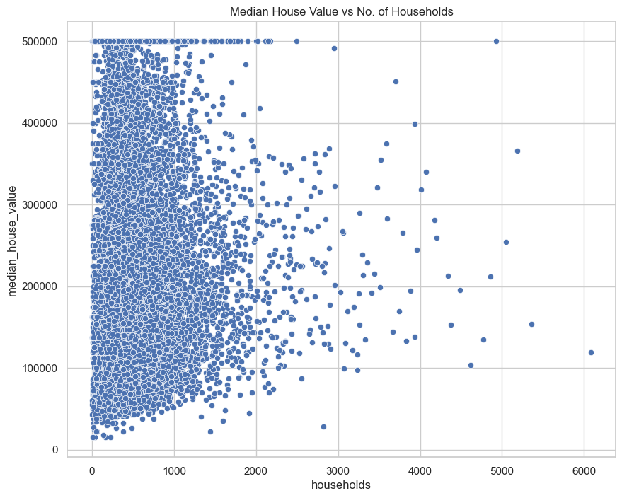

```python
plt.figure(figsize=(10, 8))
sns.scatterplot(data=df, x="households", y="median_house_value").set(title='Median House Value vs No. of Households')
plt.grid(True)
plt.show()
```

# **Linear Regression**

### **median house value vs. median income**

```python
median_income_model = linear_model.LinearRegression()
median_income_model.fit(X=df[["median_income"]], y =df[["median_house_value"]])
```

```
LinearRegression()
```

```python
median_income_model.intercept_
```

```
array([45085.57670327])
```

```python
median_income_model.coef_
```

```
array([[41793.8492019]])
```

```python
mean_absolute_error(df[["median_house_value"]],median_income_model.predict(df[["median_income"]]))
```

```
62625.9337911434
```

```python
mean_squared_error(df[["median_house_value"]],median_income_model.predict(df[["median_income"]]))
```

```
7011311502.929527
```

### **median house value vs. population**

```python
population_model = linear_model.LinearRegression()
population_model.fit(X=df[["population"]], y =df[["median_house_value"]])
```

```
LinearRegression()
```

```python
population_model.intercept_
```

```
array([210436.26207627])
```

```python
population_model.coef_
```

```
array([[-2.51175277]])
```

```python
mean_absolute_error(df[["median_house_value"]],population_model.predict(df[["population"]]))
```

```
91153.82009473183
```

```python
mean_squared_error(df[["median_house_value"]],population_model.predict(df[["population"]]))
```

```
13307412412.389355
```

### **median house value vs. number of households**

```python
households_model = linear_model.LinearRegression()
households_model.fit(X=df[["households"]], y =df[["median_house_value"]])
```

```
LinearRegression()
```

```python
households_model.intercept_
```

```
array([196928.57716233])
```

```python
households_model.coef_
```

```
array([[19.87277516]])
```

```python
mean_absolute_error(df[["median_house_value"]],households_model.predict(df[["households"]]))
```

```
90802.74324318448
```

```python
mean_squared_error(df[["median_house_value"]],households_model.predict(df[["households"]]))
```

```
13257776904.728533
```

# **Regression Summary**

| Model | Intercept | Slope | Mean Absolute Error | Mean Squared Error |
| --- | --- | --- | --- | --- |
| **Median Income** | 45085.57670327 | 41793.8492019 | `62625.9337911434` | `7011311502.929527` |
| **Population** | 210436.26207627 | -2.51175277 | 91153.82009473183 | 13307412412.389355 |
| **Households** | 196928.57716233 | 19.87277516 | 90802.74324318448 | 13257776904.728533 |

# **Plot Regression Line**

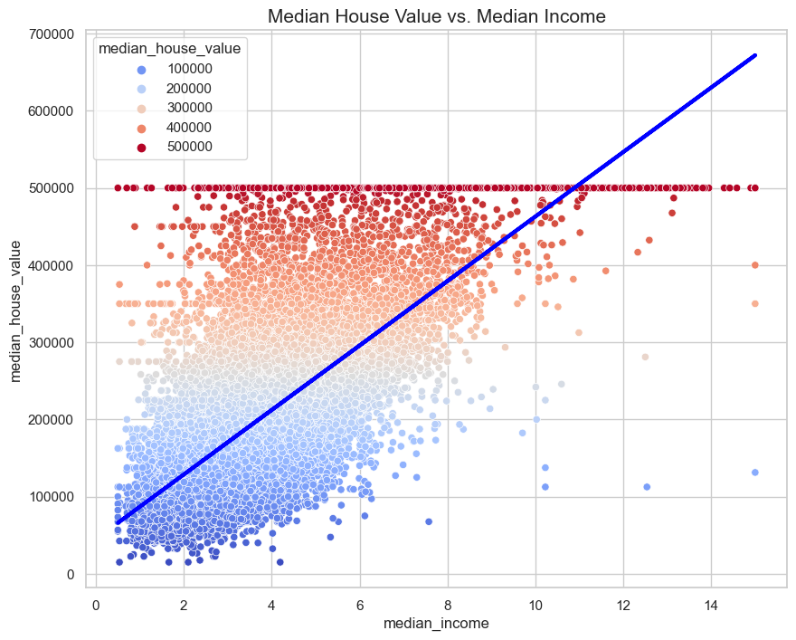

```python
plt.figure(figsize=(10, 8))
sns.scatterplot(data=df, x="median_income", y="median_house_value", hue="median_house_value", palette="coolwarm")
plt.plot(df[["median_income"]],median_income_model.predict(df[["median_income"]]), color = "blue",linewidth = 3)
plt.title('Median House Value vs. Median Income' , fontsize=15)
plt.grid(True)
plt.show()
```

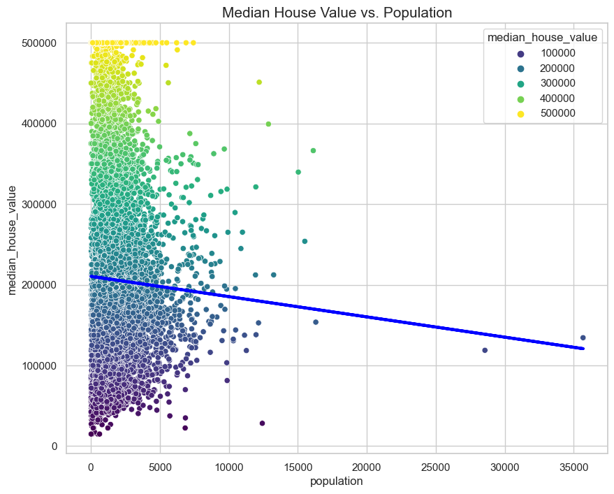

```python
plt.figure(figsize=(10, 8))
sns.scatterplot(data=df, x="population", y="median_house_value", hue="median_house_value", palette="viridis")
plt.plot(df[["population"]],population_model.predict(df[["population"]]), color = "blue",linewidth = 3)
plt.title('Median House Value vs. Population' , fontsize=15)
plt.grid(True)
plt.show()
```

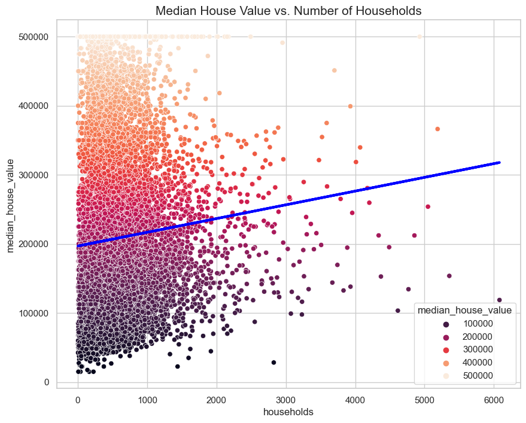

```python
plt.figure(figsize=(10, 8))
sns.scatterplot(data=df, x="households", y="median_house_value", hue="median_house_value", palette="rocket")
plt.plot(df[["households"]],households_model.predict(df[["households"]]), color = "blue",linewidth = 3)
plt.title('Median House Value vs. Number of Households', fontsize=15)
```

# **Conclusion**

The best fit among the three models is the one using 'Median Income' as the predictor variable as it has the lowest MAE and MSE. The equation of the line of best fit for the 'Median Income' model is y = 41793.85x + 45085.58 where 41793.85 is the slope and 45085.58 is the intercept

Also observed that the 'Population' model has a negative slope which suggest an inverse relationship between population and median house value.